# Epigenetic profile around exon boundaries

Gloria Li  
Wed Jul 2 17:43:28 2014

1. Profile epigenetic signals (DNA methylation, H3K4me3, H3K4me1, H3K9me3, H3K27me3, H3K36me3) around exon boundaries, i.e. exon 3-prime/5-prime +/- 200bp.
- WGBS: lumRM066 and myoRM045 bismark fractional methylation calls.
- MeDIP: lumRM035 and myoRM035 signals from wig files.
- H3K4me3: myoRM080 wig file, no libraries for lum available.
- H3K4me1, H3K9me3, H3K27me3, H3K36me3: lumRM080 and myoRM080 wig files.
2. Use exon expression and isoform analysis in RM084 lum and Rm084 myo to divide exons into four categories:
- exons expressed in both cell types: positive control
- lum-specific exons: only expressed in lum cells
- myo-specific exons: only expressed in myo cells
- exons not expressed in either cell types: negative control
3. If the epigenetic mark is associated with the isoform event, we would expect in lum cells, its signal profile for lum-specific exons is similar to expressed in both exons, and myo-specific exons similar to not expressed exons, and a reversed pattern in myo cells.

### DNA methylation profile with WGBS at exon boundaries

- Exons expressed in both cell types and exons not expressed in either cell type have distinct DNA methylation profiles.
- Profiles for isoform exons are close to exons expressed in both, without obvious distinction between two cell types.

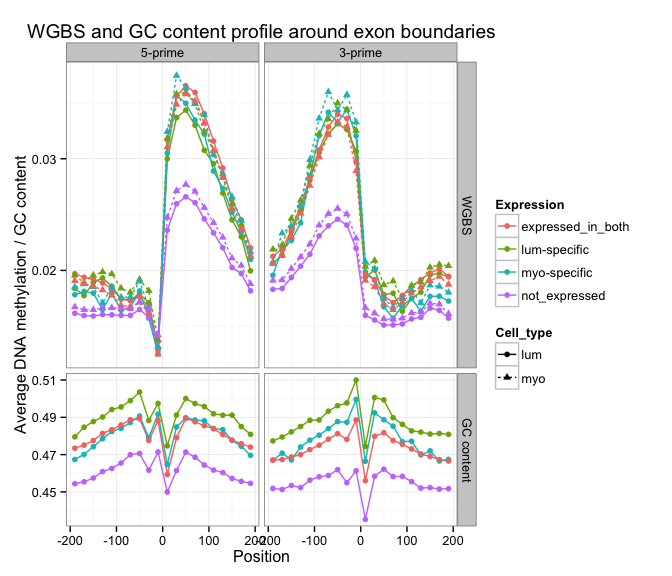

### DNA methylation profile with MeDIP at exon boundaries

- MeDIP signals are normalized between lum and myo libraries based on the sum of signals of all profiled regions.
- DNA methylation profiles are similar to results from WGBS, but the dip at exon 5-prime end is not as clear.
- Again no distinction between cell types for isoform exons.

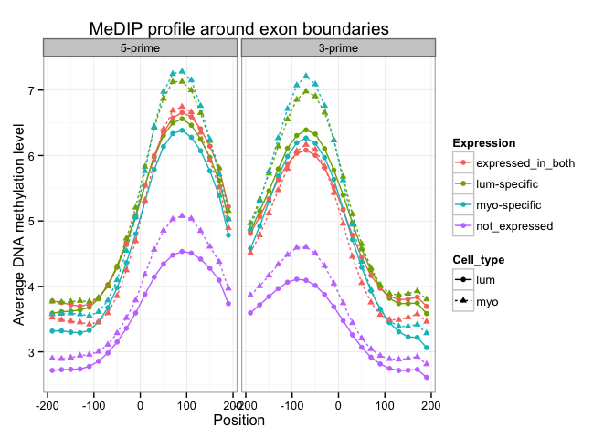

### H3K4me3 profile at exon boundaries

- No H3K4me3 libraries available for lum cells.
- H3K4me3 profiles match DNA methylation profile well.
- For myo H3K4me3 signals, expressed in both and not expressed in either exons have different profiles, but no obvious differences are observed between lum-specific and myo-specific exons.

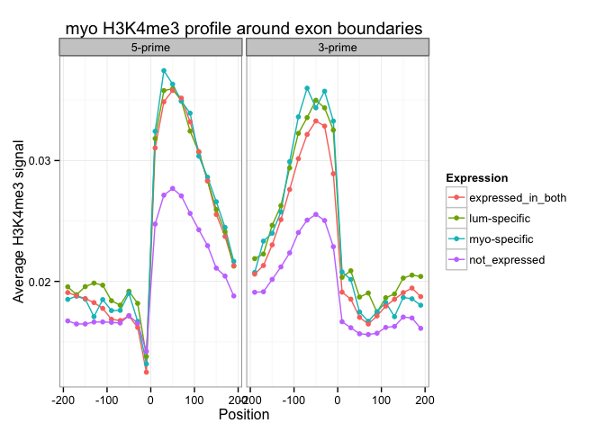

### H3K4me1 profile at exon boundaries

- H3K4me1 signals are normalized between lum and myo libraries based on the sum of signals of all profiled regions.
- Expressed in both exons and not expressed exons have distinct signal levels.
- In myo cells, profiles for the two types of isoform exons are similar.
- In lum cells, we do see expected pattern, i.e. myo-specific exons closer to not expressed exons and lum-specific exons closer to expressed in both exons.

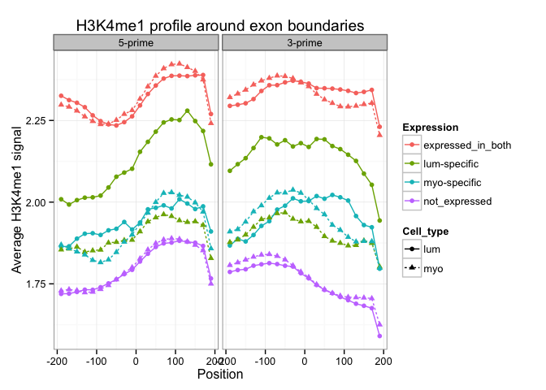

### H3K9me3 profile at exon boundaries

- H3K9me3 signals are normalized between lum and myo libraries based on the sum of signals of all profiled regions.
- Expressed in both exons and not expressed exons have distinct signal levels.
- In lum cells, profiles for the two types of isoform exons are similar.
- In myo cells, we do see expected pattern, i.e. lum-specific exons closer to not expressed exons and myo-specific exons closer to expressed in both exons. This pattern is the opposite of H3K4me1.

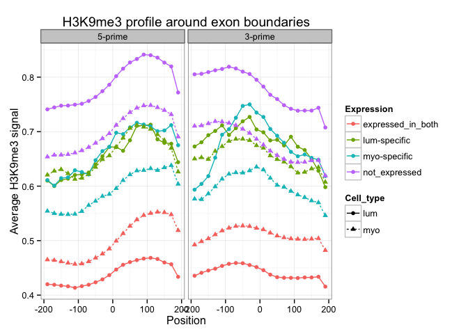

### H3K27me3 profile at exon boundaries

- H3K27me3 signals are normalized between lum and myo libraries based on the sum of signals of all profiled regions.
- In both cell types, isoform exons have signal levels close to not expressed exons.

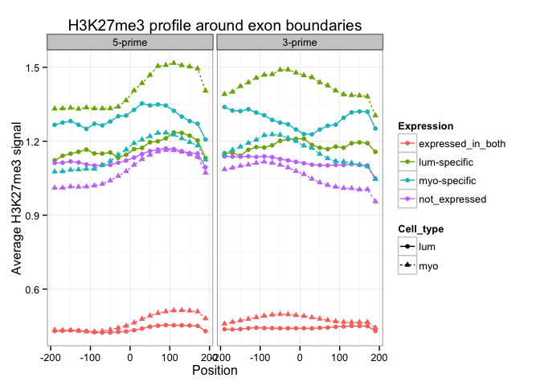

### H3K36me3 profile at exon boundaries

- H3K36me3 signals are normalized between lum and myo libraries based on the sum of signals of all profiled regions.
- Exons expressed in both cell types have a distinct profile than the rest of exons.
- Isoform exons have similar profile as not expressed exons, similar to H3K27me3.

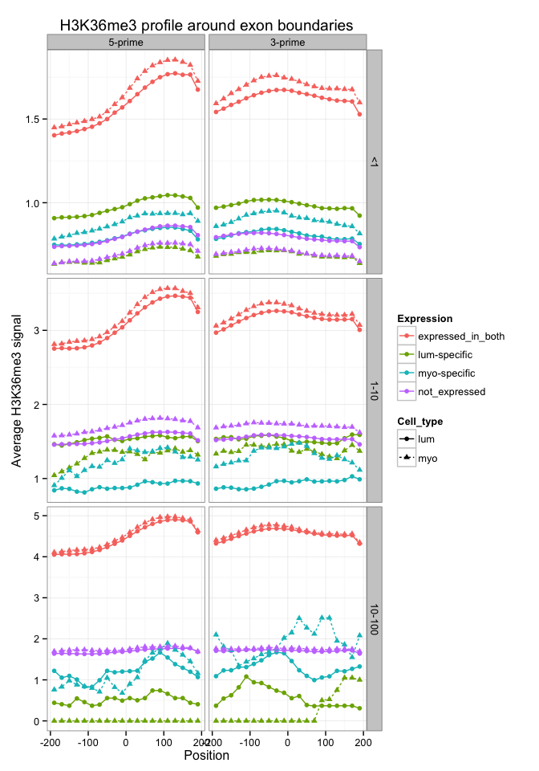

### H3K36me3 signals for exon bodies

- H3K36me3 signals are normalized between lum and myo libraries based on the sum of signals of all exons.
- Isoform exons have similar signal level as not expressed exons, significantly lower than signals in exons expressed in both cell types.
- In gene RPKM = 1-10 group, lum-specific exons have higher signal level in lum and myo-specific exons are higher in myo, however, this observation was not reproduced in gene RPKM < 1 group, probably due to the extremely low expression level.
- There are only 2 lum-specific exons with gene RPKM > 10, therefore, discard this group from plotting.

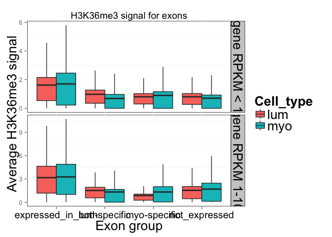